# Bayesian Power Analysis for A/B/n Tests

This post highlights a Bayesian approach to sample size estimation in A/B/n testing. Say we're trying to test which variant of an email message generates the highest response rate from a population. We consider $k$ different messages and send out $n$ emails for each message. After we wait for responses, we should be able to tell which message yielded the highest response rate as long as we set $n$ high enough. But we generally can't send out too many messages: say we're capped at $N$ total. How do we choose the highest $k$ that still allows us to confidently pick which message got the highest response rate?

We'll start with a prior over the response rates of each message. Choosing an independent prior over the rates for each message would be overly naive: all the messages will likely give very similar response rates, so if we know the rate for one message, we'll have a good guess about the rates for other messages too. Instead, we'll choose one message to be a baseline, giving it a response rate prior centered at 7%. We'll sample independent factors of this baseline to give the response rates for the other messages.

```
using LogExpFunctions, LinearAlgebra, Distributions, QuasiMonteCarlo, CairoMakie, StatsModels
```

```
priors = [Normal(logit(0.07), 0.5), Normal(log(1.1), log(1.3)), Normal(0, log(1.3))];
```

```
function plot_prior(p, transform, title)
    f = Figure()
    ax = Axis(f[1, 1], title=title)
    hist!(ax, transform.(rand(p, 1000)))
    qs = transform.(quantile.(p, [0.05, 0.5, 0.95]))
    vlines!(ax, qs, color=:orange, linestyle = :dash)
    f
end;
```

```
plot_prior(priors[1], logistic, "Control success probability")
```

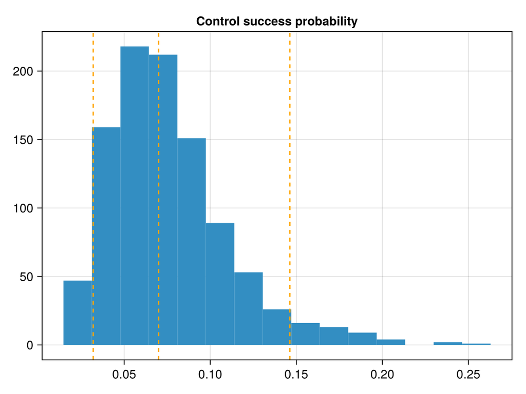

```
plot_prior(priors[2], exp, "Odds ratio for best arm")
```

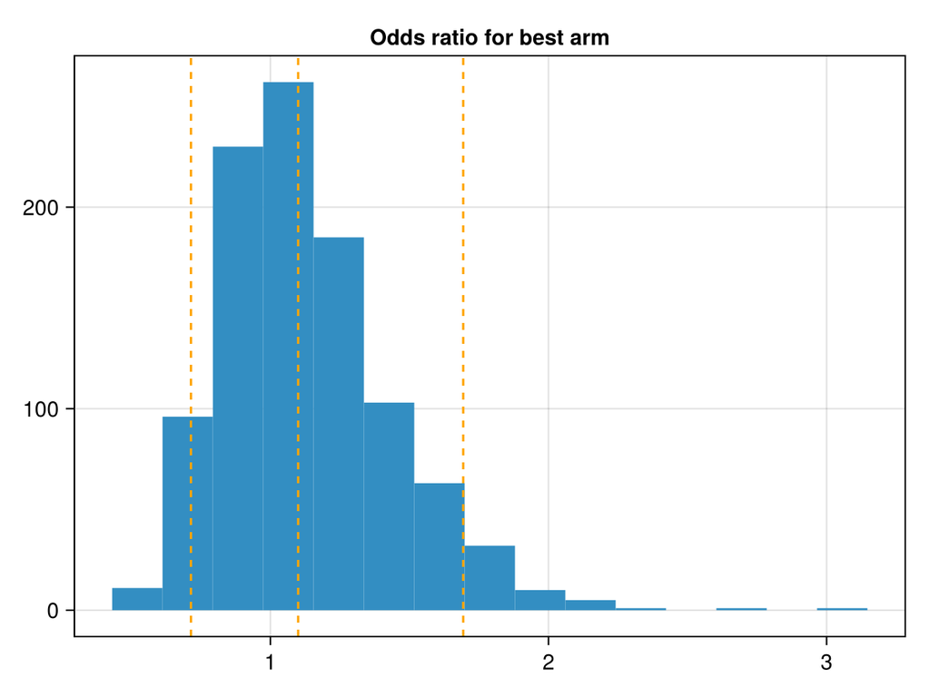

```
plot_prior(priors[3], exp, "Odds ratio for other arms")
```

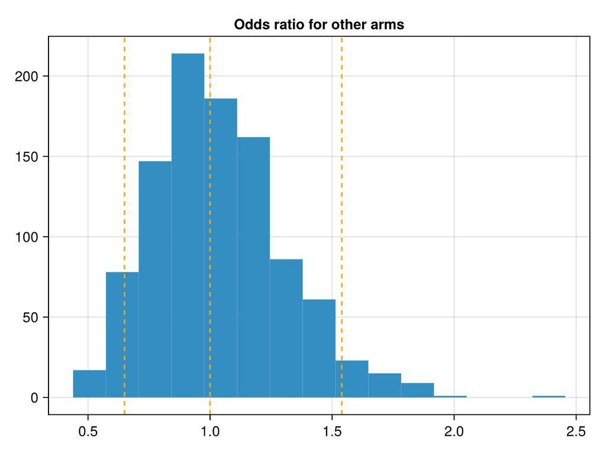

If the posterior odds ratios of the non-baseline messages all have 95% of their mass below 1.1, we'll stick with the baseline message. If, instead, any of the messages has 95% of its posterior odds ratio mass above 1.1, we'll choose one of those. If neither of these conditions occur, our experiment will have been a failure: we'll remain too uncertain to make a decision of whether or not to switch from the baseline message. Our task is to choose the number of messages to ensure that we have high probability of running a successful experiment.

To find the posterior odds ratio for each message, we'll use the Laplace approximation for Bayesian logistic regression. We'll use Newton's method to find the MAP.

```
function newton(f, x; maxiter=1000)
    for _ in 1:maxiter
        g, H = f(x)
        if norm(g) < 1e-4
            return (x, H)
        else
            x .-= H \ g
        end
    end
    error("Maximum iterations reached")
end;
```

The following code averages the decision probability over quasi Monte Carlo samples of possible datasets we might observe if the true parameters are given by θ.

```
"""If θ are the true params, what is the probability we'll be able to make
a reject/accept decision after n observations for each arm?"""
function decision_prob(θ, n, k; m=80)
    X = [ones(k,1) StatsModels.ContrastsMatrix(DummyCoding(), 1:k).matrix]
    dists = Binomial.(n, logistic.(X * θ))
    samples = QuasiMonteCarlo.sample(m, k, SobolSample())
    succs = stack([quantile.(d, s) for (d,s) in zip(dists, eachrow(samples))])
    mean(eachrow(succs)) do succs
        function gh(t)
            y = logistic.(X * t)
            vals = succs .* (y .- 1) .+ (n .- succs) .* y
            g = [sum(vals); vals[2:end]] .+ t
            H = I + sum(zip(y, eachrow(X))) do (yi, r)
                n * yi * (1 - yi) * Symmetric(r * r')
            end
            g, H
        end
        mode, H = newton(gh, Vector(θ))
        covar = inv(H)
        c = cdf.(Normal.(mode, diag(covar)), 1.1)
        Float32(all(c .> 0.95) | any(c .< 0.05))
    end
end;
```

We also need to average the decision probability over our prior for θ.

```
"""What is the probability we'll be able to make a reject/accept decision after
`total_n` observations equally divided among `k` arms?"""
function avg_decision_prob(total_n, k, m=80)
    n = div(total_n, k)
    samples = QuasiMonteCarlo.sample(m, k, SobolSample())
    full_priors = [priors; fill(priors[3], k-2)]
    prior_samples = stack([quantile.(p, c) for (p,c) in
                                  zip(full_priors, eachrow(samples))])
    mean(eachrow(prior_samples)) do θ
        decision_prob(θ, n, k)
    end
end;
```

Now, we can use these quasi Monte Carlo estimates to approximate how many messages we'll be able to test for a given sample size.

```
let
f = Figure()
ax = Axis(f[1, 1],
          yminorgridvisible=true,
          yminorticks = IntervalsBetween(5),
          title="Sample Size Requirements",
          xlabel="samples", ylabel="decision probability")
ns = 60:20:600
for k in 2:5
    probs = avg_decision_prob.(ns, k)
    lines!(ax, ns, probs, label="$k arms")
end
Legend(f[1, 2], ax)
f
end
```

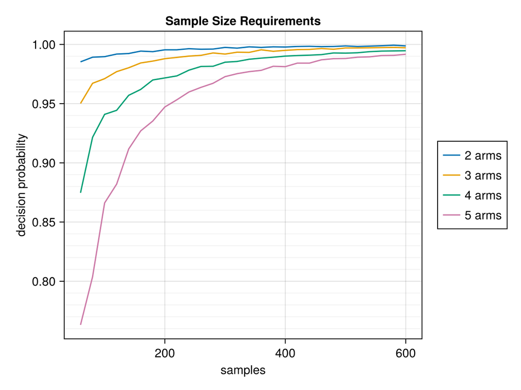